# Analysis on Ethereum blockchain

### We have chosen the three tokens as per the criteria specified in the problem statement. The modulo of sum of team member’s UTD ID by 20 is 3. The top 3rd, 4th and 5th biggest tokens are networkomisegoTX, networkyocoinTX, and networkgolemTX

## Loading libraries

```r
library(dplyr)
```

```r
library(ggplot2)
library(fitdistrplus)
```

# Question 1

## Analysis on token ‘networkgolemTX’

#### Loading token graph edge file into a dataframe

```r
networkgolemTX <- read.csv('data/networkgolemTX.txt', sep=" ", header = FALSE)
names(networkgolemTX) <- c("fromAddress", "toAddress", "unixTime", "tokenAmount")
head(networkgolemTX)
```

|  | fromAddress | toAddress | unixTime | tokenAmount |
| --- | --- | --- | --- | --- |
| 1 | 2335455 | 361874 | 1524611390 | 8.023884e+18 |
| 2 | 4067684 | 4067685 | 1524611418 | 5.000000e+22 |
| 3 | 75994 | 4067686 | 1524611727 | 1.114323e+23 |
| 4 | 297031 | 4067687 | 1524611781 | 4.661232e+19 |
| 5 | 75994 | 4067688 | 1524611836 | 9.063376e+21 |
| 6 | 4067689 | 2335455 | 1524611836 | 2.087045e+20 |

#### Checking the data type for each column

```r
str(networkgolemTX)
```

```
## 'data.frame':    684338 obs. of  4 variables:
##  $ fromAddress: int  2335455 4067684 75994 297031 75994 4067689 4067690 40002 75994 2335455 ...
##  $ toAddress  : int  361874 4067685 4067686 4067687 4067688 2335455 2335455 1810 118 3135852 ...
##  $ unixTime   : int  1524611390 1524611418 1524611727 1524611781 1524611836 1524611836 1524611836 1524611948 1524611984 1524612057 ...
##  $ tokenAmount: num  8.02e+18 5.00e+22 1.11e+23 4.66e+19 9.06e+21 ...
```

#### All columns have correct data types. We’ll now check if there are any transactions with same addresses

```r
sameTx <- networkgolemTX[networkgolemTX$fromAddress == networkgolemTX$toAddress, ]
#head(sameTx)
nrow(sameTx)
```

```
## [1] 635
```

#### It can be observed that there were 635 transactions that occured where sender and recipient have the same address.

```r
nrow(unique(sameTx["fromAddress"]))
```

```
## [1] 427
```

#### We observe that there are 427 unique addresses which have self transactions.These are malicious user transactions and we’ll remove them from our analysis.

```r
cleanedGolemTX <- networkgolemTX[networkgolemTX$fromAddress != networkgolemTX$toAddress, ]
```

#### Checking if any of the token amount exceeds the total supply of the coin, which is limited to (1 x 10^9) (https://coinmarketcap.com/currencies/golem-network-tokens/)

#### Each coin can have upto a maximum of 10^18 subunits. Therefore, the token amount that can exist in the data should be less than total supply * 10^18. Anything beyond this amount will be considered as outliers and removed from analysis.

```r
subUnits <- 10^18
totalSupply <- 1 * 10^9
outliersDf <- cleanedGolemTX[cleanedGolemTX$tokenAmount > totalSupply * subUnits,]
nrow(outliersDf)
```

```
## [1] 25
```

#### It can be observed that for 25 transactions, the token amount is larger than the expected total supply of the coins. This anomaly can be attributed to the BatchOverflow Exploit which resulted in generating astronomical values. We’ll remove such transaction from our analysis.

#### After removing the invalid transactions, we’ll generate the ‘buy’ distribution. This will contain the frequency of number of buys performed by users

```r
filteredGolemTX <- cleanedGolemTX[cleanedGolemTX$tokenAmount <= totalSupply * subUnits,]
#buys.distribution <- filteredGolemTX %>% group_by(toNode) %>% summarise(n = n()) %>% ungroup
pair.users.buys <- filteredGolemTX %>% group_by(toAddress) %>% summarise(n = n(), sumAmount=sum(tokenAmount)) %>% ungroup
head(pair.users.buys)
```

| toAddress | n | sumAmount |
| --- | --- | --- |
| 5 | 3709 | 5.148434e+25 |
| 6 | 33 | 6.738161e+24 |
| 7 | 622 | 2.544117e+25 |
| 8 | 345 | 2.782612e+25 |
| 13 | 22 | 2.501980e+25 |
| 17 | 11 | 5.844694e+21 |

### Plotting density distribution for ‘Buy’ transactions. We’ll check if we are able to identify frequency of number of buys between 2 users

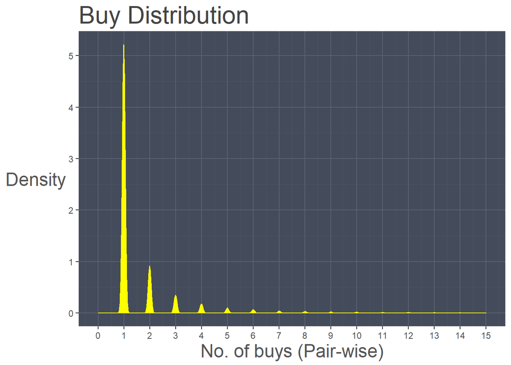

```r
ggplot(data=pair.users.buys, aes(pair.users.buys$n)) +
  geom_density(fill='yellow', color='yellow') +
  scale_x_continuous(breaks=seq(0,15,1), limits=c(0,15)) +
  xlab("No. of buys (Pair-wise)") +
  ylab("Density") +
  ggtitle("Buy Distribution") +
  theme(text = element_text(color = "#444444")
        ,panel.background = element_rect(fill = '#444B5A')
        ,panel.grid.minor = element_line(color = '#4d5566')
        ,panel.grid.major = element_line(color = '#586174')
        ,plot.title = element_text(size = 24)
        ,axis.title = element_text(size = 18, color = '#555555')
        ,axis.title.y = element_text(vjust = .5, angle = 0)
        ,axis.title.x = element_text(hjust = .5)
  )
```

### Similarly, we’ll generate the ‘sell’ distribution. This will contain the frequency of number of sells performed by users

```r
pair.users.sells <- filteredGolemTX %>% group_by(fromAddress) %>% summarise(n = n(), sumAmount=sum(tokenAmount))
head(pair.users.sells)
```

| fromAddress | n | sumAmount |
| --- | --- | --- |
| 5 | 808 | 5.154725e+25 |
| 6 | 620 | 6.713788e+24 |
| 7 | 195 | 2.544117e+25 |
| 8 | 1074 | 2.252453e+25 |
| 13 | 3528 | 5.259180e+25 |
| 17 | 67975 | 4.253913e+26 |

### Plotting density distribution for ‘Sell’ transactions

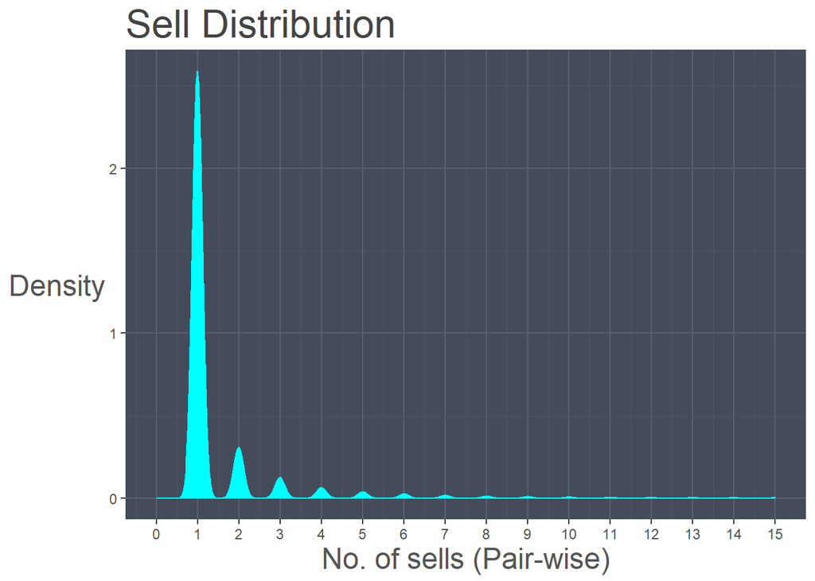

```r
ggplot(data=pair.users.sells, aes(pair.users.sells$n)) +
  geom_density(fill='cyan', color='cyan') +
  scale_x_continuous(breaks=seq(0,15,1), limits=c(0,15)) +
  xlab("No. of sells (Pair-wise)") +
  ylab("Density") +
  ggtitle("Sell Distribution") +
  theme(text = element_text(color = "#444444")
        ,panel.background = element_rect(fill = '#444B5A')
        ,panel.grid.minor = element_line(color = '#4d5566')
        ,panel.grid.major = element_line(color = '#586174')
        ,plot.title = element_text(size = 24)
        ,axis.title = element_text(size = 18, color = '#555555')
        ,axis.title.y = element_text(vjust = .5, angle = 0)
        ,axis.title.x = element_text(hjust = .5)
  )
```

### Now that we have seen density distributions for both types of transactions, we’ll individually fit the data in different distribution models

```r
fit.buy.norm <- fitdist(pair.users.buys$n, "norm")
fit.buy.weibull  <- fitdist(pair.users.buys$n, "weibull")
fit.buy.gamma  <- fitdist(pair.users.buys$n, "gamma")
fit.buy.lnorm <- fitdist(pair.users.buys$n, "lnorm")
fit.buy.exp <- fitdist(pair.users.buys$n, "exp")
fit.buy.logis <- fitdist(pair.users.buys$n, "logis")
```

#### Plotting all distributions and check which one satisfies our ‘Buy’ distribution

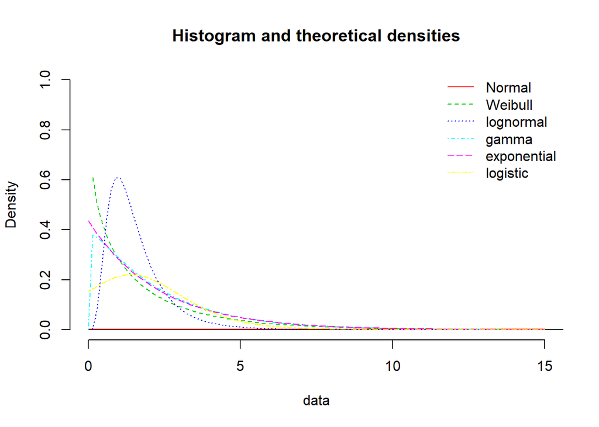

```r
#par(mfrow=c(2,2))
plot.legend <- c("Normal", "Weibull", "lognormal", "gamma", "exponential", "logistic")
denscomp(list(fit.buy.norm,fit.buy.weibull , fit.buy.lnorm, fit.buy.gamma, fit.buy.exp,fit.buy.logis), legendtext = plot.legend, xlim=c(0,15), ylim=c(0,1))
```

```r
gofstat(list(fit.buy.norm,fit.buy.weibull , fit.buy.lnorm, fit.buy.gamma, fit.buy.exp,fit.buy.logis),fitnames = c("Normal", "Weibull", "Lognormal", "Gamma", "Exponential", "Logistic"))
```

```
## Goodness-of-fit statistics
##                                    Normal      Weibull    Lognormal
## Kolmogorov-Smirnov statistic 4.970187e-01     0.456095     0.432795
## Cramer-von Mises statistic   2.442256e+04 12829.812628 11162.251459
## Anderson-Darling statistic            Inf          Inf          Inf
##                                     Gamma  Exponential     Logistic
## Kolmogorov-Smirnov statistic 3.990184e-01 3.872291e-01 4.096837e-01
## Cramer-von Mises statistic   1.299649e+04 1.279001e+04 1.195114e+04
## Anderson-Darling statistic            Inf          Inf          Inf
##
## Goodness-of-fit criteria
##                                 Normal Weibull Lognormal   Gamma
## Akaike's Information Criterion 3923301 1022999  690476.8 1091218
## Bayesian Information Criterion 3923323 1023021  690498.0 1091239
##                                Exponential Logistic
## Akaike's Information Criterion     1091889  1417136
## Bayesian Information Criterion     1091899  1417157
```

#### From the goodness of fit statistics and the previous graph, it seems lognormal is a better fit than the rest.

#### Estimating parmaters for this distribution

```r
fit.buy.lnorm
```

```
## Fitting of the distribution ' lnorm ' by maximum likelihood
## Parameters:
##          estimate   Std. Error
## meanlog 0.2885247 0.0010545595
## sdlog   0.5762432 0.0007456761
```

```r
ests.buys <- bootdist(fit.buy.lnorm, niter = 100)
summary(ests.buys)
```

```
## Parametric bootstrap medians and 95% percentile CI
##            Median      2.5%     97.5%
## meanlog 0.2885807 0.2867006 0.2911573
## sdlog   0.5762220 0.5749936 0.5777916
```

#### Now fitting distributions for sell transactions…

```r
fit.sell.norm <- fitdist(pair.users.sells$n, "norm")
fit.sell.weibull  <- fitdist(pair.users.sells$n, "weibull")
fit.sell.gamma  <- fitdist(pair.users.sells$n, "gamma")
fit.sell.lnorm <- fitdist(pair.users.sells$n, "lnorm")
fit.sell.exp <- fitdist(pair.users.sells$n, "exp")
fit.sell.logis <- fitdist(pair.users.sells$n, "logis")
```

#### Plotting all distributions and check which one satisfies our ‘Sell’ distribution

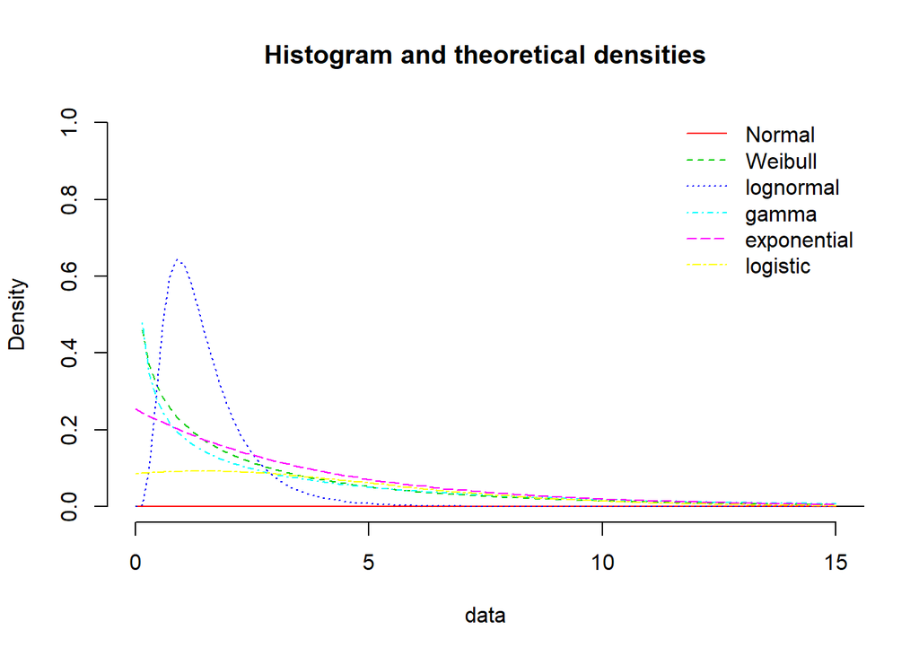

```r
plot.legend <- c("Normal","Weibull", "lognormal", "gamma", "exponential", "logistic")
denscomp(list(fit.sell.norm, fit.sell.weibull, fit.sell.lnorm, fit.sell.gamma, fit.sell.exp,fit.sell.logis), legendtext = plot.legend, xlim=c(0,15), ylim=c(0,1))
```

```r
gofstat(list(fit.sell.norm, fit.sell.weibull,fit.sell.lnorm,fit.sell.gamma,fit.sell.exp,fit.sell.logis),fitnames = c("Normal", "Weibull", "Lognormal", "Gamma", "Exponential", "Logistic"))
```

```
## Goodness-of-fit statistics
##                                    Normal      Weibull    Lognormal
## Kolmogorov-Smirnov statistic 4.974599e-01 4.490602e-01    0.4613547
## Cramer-von Mises statistic   1.439686e+04 1.026181e+04 7993.0130687
## Anderson-Darling statistic            Inf          Inf          Inf
##                                     Gamma  Exponential     Logistic
## Kolmogorov-Smirnov statistic 4.366792e-01 5.729911e-01 4.578689e-01
## Cramer-von Mises statistic   1.057106e+04 1.638435e+04 1.007920e+04
## Anderson-Darling statistic            Inf          Inf          Inf
##
## Goodness-of-fit criteria
##                                 Normal  Weibull Lognormal    Gamma
## Akaike's Information Criterion 2628308 641758.2  383593.2 772831.3
## Bayesian Information Criterion 2628328 641778.3  383613.4 772851.4
##                                Exponential Logistic
## Akaike's Information Criterion    824394.1  1158600
## Bayesian Information Criterion    824404.2  1158620
```

#### From the goodness of fit statistics and the previous graph, it seems lognormal is a better fit than the rest

#### Estimating parmaters for this distribution

```r
fit.sell.lnorm
```

```
## Fitting of the distribution ' lnorm ' by maximum likelihood
## Parameters:
##          estimate   Std. Error
## meanlog 0.2415419 0.0013709982
## sdlog   0.5719955 0.0009694288
```

```r
ests.sells <- bootdist(fit.sell.lnorm, niter = 100)
summary(ests.sells)
```

```
## Parametric bootstrap medians and 95% percentile CI
##            Median      2.5%     97.5%
## meanlog 0.2414647 0.2390273 0.2442630
## sdlog   0.5720011 0.5699265 0.5735031
```

## Analysis on token ‘networkyocoinTX’

#### Loading token graph edge file into a dataframe

```r
networkyocoinTX <- read.csv('data/networkyocoinTX.txt', sep=" ", header = FALSE)
names(networkyocoinTX) <- c("fromAddress", "toAddress", "unixTime", "tokenAmount")
head(networkyocoinTX)
```

|  | fromAddress | toAddress | unixTime | tokenAmount |
| --- | --- | --- | --- | --- |
| 1 | 9911592 | 9911593 | 1517342415 | 5.0e+16 |
| 2 | 9911594 | 9911595 | 1517818943 | 1.0e+19 |
| 3 | 9911596 | 9911597 | 1515768296 | 5.0e+16 |
| 4 | 9911598 | 9911599 | 1512953126 | 1.3e+18 |
| 5 | 9911600 | 9911601 | 1512953651 | 8.0e+16 |
| 6 | 9911602 | 9911594 | 1512967870 | 1.0e+19 |

#### Checking the data type for each column

```r
str(networkyocoinTX)
```

```
## 'data.frame':    746397 obs. of  4 variables:
##  $ fromAddress: int  9911592 9911594 9911596 9911598 9911600 9911602 9911598 9911603 9911605 9911606 ...
##  $ toAddress  : int  9911593 9911595 9911597 9911599 9911601 9911594 9911599 9911604 5496939 9911607 ...
##  $ unixTime   : int  1517342415 1517818943 1515768296 1512953126 1512953651 1512967870 1512971620 1513141671 1513607144 1513620522 ...
##  $ tokenAmount: num  5.0e+16 1.0e+19 5.0e+16 1.3e+18 8.0e+16 ...
```

#### All columns have correct data types. We’ll now check if there are any transactions with same addresses

```r
sameTxYocoin <- networkyocoinTX[networkyocoinTX$fromAddress == networkyocoinTX$toAddress, ]
nrow(sameTxYocoin)
```

```
## [1] 631
```

```r
nrow(unique(sameTxYocoin["fromAddress"]))
```

```
## [1] 4
```

#### We observe that there are 4 unique addresses which have self transactions.These are malicious user transactions and we’ll remove them from our analysis.

```r
cleanedYocoinTX <- networkyocoinTX[networkyocoinTX$fromAddress != networkyocoinTX$toAddress, ]
```

#### Checking if any of the token amount exceeds the total supply of the coin, which is limited to (554925923) (https://coinmarketcap.com/currencies/yocoin/)

#### Each coin can have upto a maximum of 10^18 subunits. Therefore, the token amount that can exist in the data should be less than total supply * 10^18. Anything beyond this amount will be considered as outliers and removed from analysis.

```r
subUnits.yocoin <- 10^18
totalSupply.yocoin <- 554925923
outliersDf.yocoin <- cleanedYocoinTX[cleanedYocoinTX$tokenAmount > totalSupply.yocoin * subUnits.yocoin,]
nrow(outliersDf.yocoin)
```

```
## [1] 90
```

#### It can be observed that for 90 transactions, the token amount is larger than the expected total supply of the coins. This anomaly can be attributed to the BatchOverflow Exploit which resulted in generating astronomical values. We’ll remove such transaction from our analysis.

#### After removing the invalid transactions, we’ll generate the ‘buy’ distribution. This will contain the frequency of number of buys performed by users

```r
filteredYocoinTX <- cleanedYocoinTX[cleanedYocoinTX$tokenAmount <= totalSupply.yocoin * subUnits.yocoin,]
#buys.distribution <- filteredGolemTX %>% group_by(toNode) %>% summarise(n = n()) %>% ungroup
yocoin.pair.users.buys <- filteredYocoinTX %>% group_by(toAddress) %>% summarise(n = n(), sumAmount=sum(tokenAmount)) %>% ungroup
head(yocoin.pair.users.buys)
```

| toAddress | n | sumAmount |
| --- | --- | --- |
| 14514 | 1 | 4.935000e+19 |
| 16853 | 3 | 2.981109e+18 |
| 29745 | 3 | 4.331239e+22 |
| 48730 | 1 | 2.230793e+17 |
| 104010 | 1 | 1.000000e+18 |
| 186374 | 1 | 1.819020e+16 |

### Plotting density distribution for ‘Buy’ transactions. We’ll check if we are able to identify frequency of number of buys between 2 users

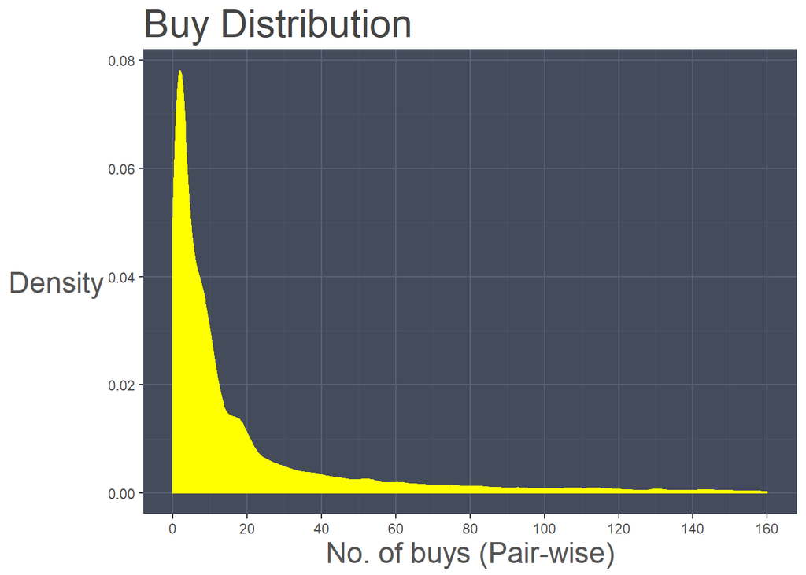

```r
ggplot(data=yocoin.pair.users.buys, aes(yocoin.pair.users.buys$n)) +
  geom_density(fill='yellow', color='yellow') +
  scale_x_continuous(breaks=seq(0,160,20), limits=c(0,160)) +
  xlab("No. of buys (Pair-wise)") +
  ylab("Density") +
  ggtitle("Buy Distribution") +
  theme(text = element_text(color = "#444444")
        ,panel.background = element_rect(fill = '#444B5A')
        ,panel.grid.minor = element_line(color = '#4d5566')
        ,panel.grid.major = element_line(color = '#586174')
        ,plot.title = element_text(size = 24)
        ,axis.title = element_text(size = 18, color = '#555555')
        ,axis.title.y = element_text(vjust = .5, angle = 0)
        ,axis.title.x = element_text(hjust = .5)
  )
```

###Similarly, we’ll generate the ‘sell’ distribution. This will contain the frequency of number of sells performed by users

```r
yocoin.pair.users.sells <- filteredYocoinTX %>% group_by(fromAddress) %>% summarise(n = n(), sumAmount=sum(tokenAmount))
head(yocoin.pair.users.sells)
```

| fromAddress | n | sumAmount |
| --- | --- | --- |
| 309659 | 4103 | 1.013505e+24 |
| 336069 | 133 | 2.983406e+22 |
| 467727 | 3 | 9.004334e+19 |
| 483085 | 64 | 7.850805e+21 |
| 1380386 | 2 | 2.875464e+20 |
| 1387470 | 2 | 8.965245e+20 |

#### Plotting density distribution for ‘Sell’ transactions

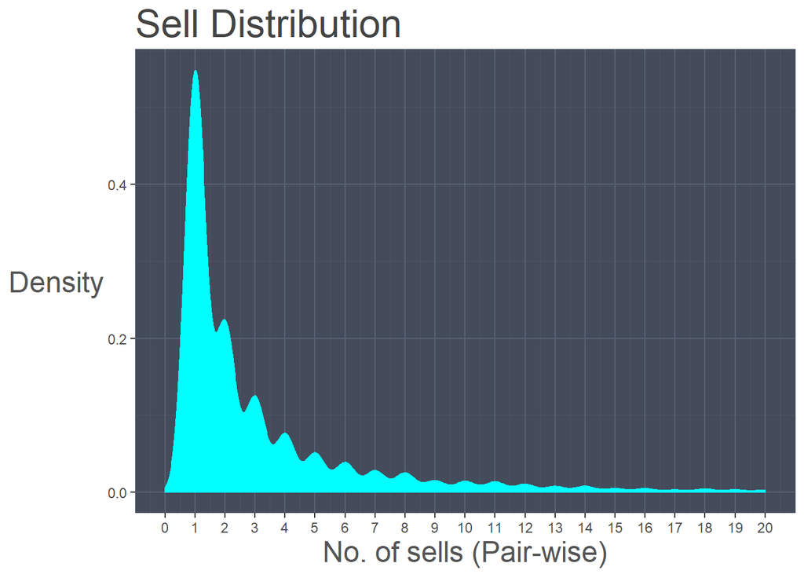

```r
ggplot(data=yocoin.pair.users.sells, aes(yocoin.pair.users.sells$n)) +
  geom_density(fill='cyan', color='cyan') +
  scale_x_continuous(breaks=seq(0,20,1), limits=c(0,20)) +
  xlab("No. of sells (Pair-wise)") +
  ylab("Density") +
  ggtitle("Sell Distribution") +
  theme(text = element_text(color = "#444444")
        ,panel.background = element_rect(fill = '#444B5A')
        ,panel.grid.minor = element_line(color = '#4d5566')
        ,panel.grid.major = element_line(color = '#586174')
        ,plot.title = element_text(size = 24)
        ,axis.title = element_text(size = 18, color = '#555555')
        ,axis.title.y = element_text(vjust = .5, angle = 0)
        ,axis.title.x = element_text(hjust = .5)
  )
```

###Now that we have seen density distributions for both types of transactions, we’ll individually fit the data in different distribution models

```r
yocoin.fit.buy.norm <- fitdist(yocoin.pair.users.buys$n, "norm")
yocoin.fit.buy.weibull <- fitdist(yocoin.pair.users.buys$n, "weibull")
yocoin.fit.buy.gamma <- fitdist(yocoin.pair.users.buys$n, "gamma")
yocoin.fit.buy.lnorm <- fitdist(yocoin.pair.users.buys$n, "lnorm")
yocoin.fit.buy.exp <- fitdist(yocoin.pair.users.buys$n, "exp")
yocoin.fit.buy.logis <- fitdist(yocoin.pair.users.buys$n, "logis")
```

#### Plotting all distributions and check which one satisfies our ‘Buy’ distribution

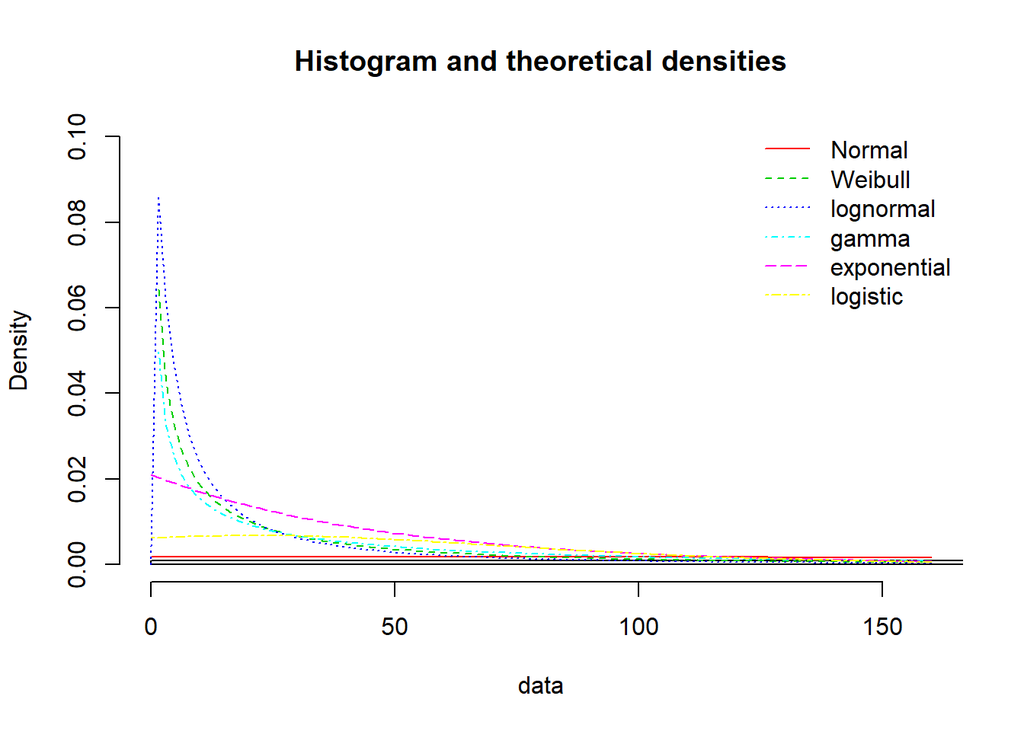

```r
plot.legend <- c("Normal", "Weibull", "lognormal", "gamma", "exponential", "logistic")
denscomp(list(yocoin.fit.buy.norm,yocoin.fit.buy.weibull , yocoin.fit.buy.lnorm, yocoin.fit.buy.gamma, yocoin.fit.buy.exp,yocoin.fit.buy.logis), legendtext = plot.legend, xlim=c(0,160), ylim=c(0,0.1))
```

```r
gofstat(list(yocoin.fit.buy.norm,yocoin.fit.buy.weibull , yocoin.fit.buy.lnorm, yocoin.fit.buy.gamma, yocoin.fit.buy.exp,yocoin.fit.buy.logis),fitnames = c("Normal", "Weibull", "Lognormal", "Gamma", "Exponential", "Logistic"))
```

```
## Goodness-of-fit statistics
##                                   Normal     Weibull   Lognormal
## Kolmogorov-Smirnov statistic   0.4146914   0.1670572   0.0910452
## Cramer-von Mises statistic   837.2258143  66.7021970  17.5966375
## Anderson-Darling statistic           Inf 449.2154012 161.2311097
##                                    Gamma  Exponential    Logistic
## Kolmogorov-Smirnov statistic   0.1901254    0.3901345   0.3646005
## Cramer-von Mises statistic   195.6824678 1006.9359569 453.2672980
## Anderson-Darling statistic           Inf          Inf         Inf
##
## Goodness-of-fit criteria
##                                  Normal  Weibull Lognormal    Gamma
## Akaike's Information Criterion 213088.5 134580.6  129937.9 139184.7
## Bayesian Information Criterion 213103.8 134595.9  129953.2 139200.0
##                                Exponential Logistic
## Akaike's Information Criterion    152479.1 182363.4
## Bayesian Information Criterion    152486.7 182378.7
```

#### From the goodness of fit statistics and the previous graph, it seems lognormal is a better fit than the rest.

#### Estimating parmaters for this distribution

```r
yocoin.fit.buy.lnorm
```

```
## Fitting of the distribution ' lnorm ' by maximum likelihood
## Parameters:
##         estimate  Std. Error
## meanlog 2.216576 0.013265610
## sdlog   1.661170 0.009380187
```

```r
yocoin.ests.buys <- bootdist(yocoin.fit.buy.lnorm, niter = 1000)
summary(yocoin.ests.buys)
```

```
## Parametric bootstrap medians and 95% percentile CI
##           Median    2.5%    97.5%
## meanlog 2.215910 2.19193 2.241319
## sdlog   1.661035 1.64272 1.679503
```

#### Now fitting distributions for sell transactions.

```r
yocoin.fit.sell.norm <- fitdist(yocoin.pair.users.sells$n, "norm")
yocoin.fit.sell.weibull <- fitdist(yocoin.pair.users.sells$n, "weibull")
yocoin.fit.sell.gamma <- fitdist(yocoin.pair.users.sells$n, "gamma")
yocoin.fit.sell.lnorm <- fitdist(yocoin.pair.users.sells$n, "lnorm")
yocoin.fit.sell.exp <- fitdist(yocoin.pair.users.sells$n, "exp")
yocoin.fit.sell.logis <- fitdist(yocoin.pair.users.sells$n, "logis")
```

### Plotting all distributions and check which one satisfies our ‘Sell’ distribution

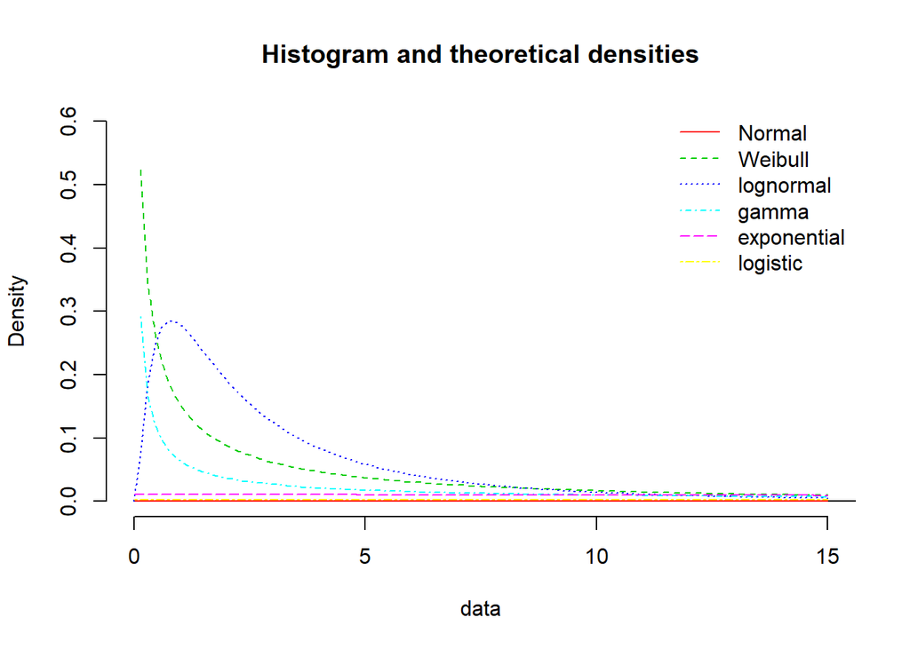

```r
plot.legend <- c("Normal","Weibull", "lognormal", "gamma", "exponential", "logistic")
denscomp(list(yocoin.fit.sell.norm, yocoin.fit.sell.weibull, yocoin.fit.sell.lnorm, yocoin.fit.sell.gamma, yocoin.fit.sell.exp,yocoin.fit.sell.logis),plotstyle = "graphics", legendtext = plot.legend, xlim=c(0,15), ylim=c(0,0.6))
```

```r
gofstat(list(yocoin.fit.sell.norm, yocoin.fit.sell.weibull, yocoin.fit.sell.lnorm, yocoin.fit.sell.gamma, yocoin.fit.sell.exp,yocoin.fit.sell.logis),fitnames = c("Normal", "Weibull", "Lognormal", "Gamma", "Exponential", "Logistic"))
```

```
## Goodness-of-fit statistics
##                                   Normal    Weibull  Lognormal       Gamma
## Kolmogorov-Smirnov statistic   0.4948287   0.386072  0.2355341   0.4142792
## Cramer-von Mises statistic   673.4024818 201.825519 81.2617214 508.9603200
## Anderson-Darling statistic           Inf        Inf        Inf         Inf
##                              Exponential    Logistic
## Kolmogorov-Smirnov statistic    0.815979   0.4892786
## Cramer-von Mises statistic   2214.196711 619.0460399
## Anderson-Darling statistic           Inf         Inf
##
## Goodness-of-fit criteria
##                                  Normal  Weibull Lognormal    Gamma
## Akaike's Information Criterion 164061.2 45681.33  37189.82 58866.71
## Bayesian Information Criterion 164075.2 45695.34  37203.83 58880.72
##                                Exponential Logistic
## Akaike's Information Criterion    89799.81 111560.8
## Bayesian Information Criterion    89806.81 111574.8
```

#### From the goodness of fit statistics and the previous graph, it seems lognormal is a better fit than the rest

#### Estimating parmaters for this distribution

```r
yocoin.fit.sell.lnorm
```

```
## Fitting of the distribution ' lnorm ' by maximum likelihood
## Parameters:
##          estimate  Std. Error
## meanlog 0.8343167 0.011443193
## sdlog   1.0322369 0.008091525
```

```r
yocoin.ests.sells <- bootdist(yocoin.fit.sell.lnorm, niter = 100)
summary(yocoin.ests.sells)
```

```
## Parametric bootstrap medians and 95% percentile CI
##            Median      2.5%     97.5%
## meanlog 0.8356803 0.8141663 0.8511045
## sdlog   1.0310057 1.0170768 1.0482719
```

## Analysis on token ‘networkomisegoTX’

#### Loading token graph edge file into a dataframe

```r
networkomisegoTX <- read.csv('data/networkomisegoTX.txt', sep=" ", header = FALSE)
names(networkomisegoTX) <- c("fromAddress", "toAddress", "unixTime", "tokenAmount")
head(networkomisegoTX)
```

|  | fromAddress | toAddress | unixTime | tokenAmount |
| --- | --- | --- | --- | --- |
| 1 | 5186357 | 75994 | 1524611290 | 2.465000e+19 |
| 2 | 13 | 168381 | 1524611320 | 1.700000e+21 |
| 3 | 142341 | 75994 | 1524611536 | 5.301102e+21 |
| 4 | 5186358 | 297278 | 1524611536 | 2.992292e+19 |
| 5 | 5186359 | 297278 | 1524611536 | 2.214251e+18 |
| 6 | 5186360 | 297278 | 1524611536 | 2.166550e+19 |

#### We’ll now check if there are any transactions with same addresses

```r
sameTxomisegoTX <- networkomisegoTX[networkomisegoTX$fromAddress == networkomisegoTX$toAddress, ]
nrow(sameTxomisegoTX)
```

```
## [1] 30347
```

#### It can be observed that there were 30347 transactions that occured where sender and recipient have the same address

```r
nrow(unique(sameTxomisegoTX["fromAddress"]))
```

```
## [1] 259
```

#### We observe that there are 259 unique addresses which have self transactions.These are malicious user transactions and we’ll remove them from our analysis

```r
cleanedOmisegoTX <- networkomisegoTX[networkomisegoTX$fromAddress != networkomisegoTX$toAddress, ]
```

#### Checking if any of the token amount exceeds the total supply of the coin, which is limited to 140,245,398 (https://coinmarketcap.com/currencies/omisego/)

#### Each coin can have upto a maximum of 10^18 subunits. Therefore, the token amount that can exist in the data should be less than total supply * 10^18. Anything beyond this amount will be considered as outliers and removed from analysis.

```r
subUnits.omisego <- 10^18
totalSupply.omisego <- 140245398
outliersDf.omisego <- cleanedOmisegoTX[cleanedOmisegoTX$tokenAmount > totalSupply.omisego * subUnits.omisego,]
nrow(outliersDf.omisego)
```

```
## [1] 10
```

#### It can be observed that for 10 transactions, the token amount is larger than the expected total supply of the coins. This anomaly can be attributed to the BatchOverflow Exploit which resulted in generating astronomical values. We’ll remove such transaction from our analysis.

#### After removing the invalid transactions, we’ll generate the ‘buy’ distribution. This will contain the frequency of number of buys performed by users

```r
filteredOmisegoTX <- cleanedOmisegoTX[cleanedOmisegoTX$tokenAmount <= totalSupply.omisego * subUnits.omisego,]
omisego.pair.users.buys <- filteredOmisegoTX %>% group_by(toAddress) %>% summarise(n = n(), sumAmount=sum(tokenAmount)) %>% ungroup
head(omisego.pair.users.buys)
```

| toAddress | n | sumAmount |
| --- | --- | --- |
| 0 | 1 | 4.004273e+19 |
| 1 | 1 | 4.004273e+19 |
| 2 | 2 | 7.907116e+19 |
| 3 | 1 | 9.000000e+18 |
| 4 | 132 | 3.456086e+22 |
| 5 | 57315 | 5.233511e+25 |

### Plotting density distribution for ‘Buy’ transactions. We’ll check if we are able to identify frequency of number of buys between 2 users

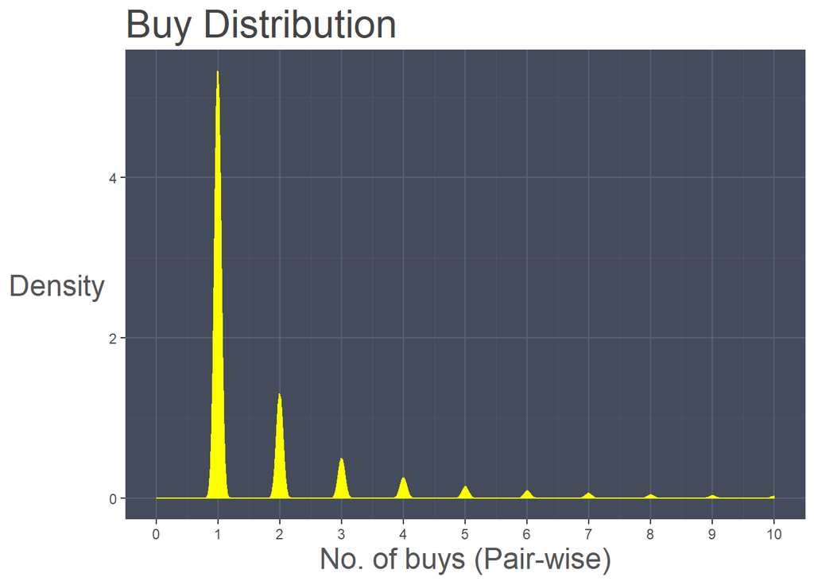

```r
ggplot(data=omisego.pair.users.buys, aes(omisego.pair.users.buys$n)) +
  geom_density(fill='yellow', color='yellow') +
  scale_x_continuous(breaks=seq(0,10,1), limits=c(0,10)) +
  xlab("No. of buys (Pair-wise)") +
  ylab("Density") +
  ggtitle("Buy Distribution") +
  theme(text = element_text(color = "#444444")
        ,panel.background = element_rect(fill = '#444B5A')
        ,panel.grid.minor = element_line(color = '#4d5566')
        ,panel.grid.major = element_line(color = '#586174')
        ,plot.title = element_text(size = 24)
        ,axis.title = element_text(size = 18, color = '#555555')
        ,axis.title.y = element_text(vjust = .5, angle = 0)
        ,axis.title.x = element_text(hjust = .5)
  )
```

###Similarly, we’ll generate the ‘sell’ distribution. This will contain the frequency of number of sells performed by users

```r
omisego.pair.users.sells <- filteredOmisegoTX %>% group_by(fromAddress) %>% summarise(n = n(), sumAmount=sum(tokenAmount))
head(omisego.pair.users.sells)
```

| fromAddress | n | sumAmount |
| --- | --- | --- |
| 0 | 1 | 4.004273e+19 |
| 2 | 1 | 9.000000e+18 |
| 4 | 123 | 1.743365e+23 |
| 5 | 48528 | 3.181295e+25 |
| 6 | 10806 | 3.651451e+24 |
| 7 | 139 | 2.779102e+24 |

### Plotting density distribution for ‘Sell’ transactions

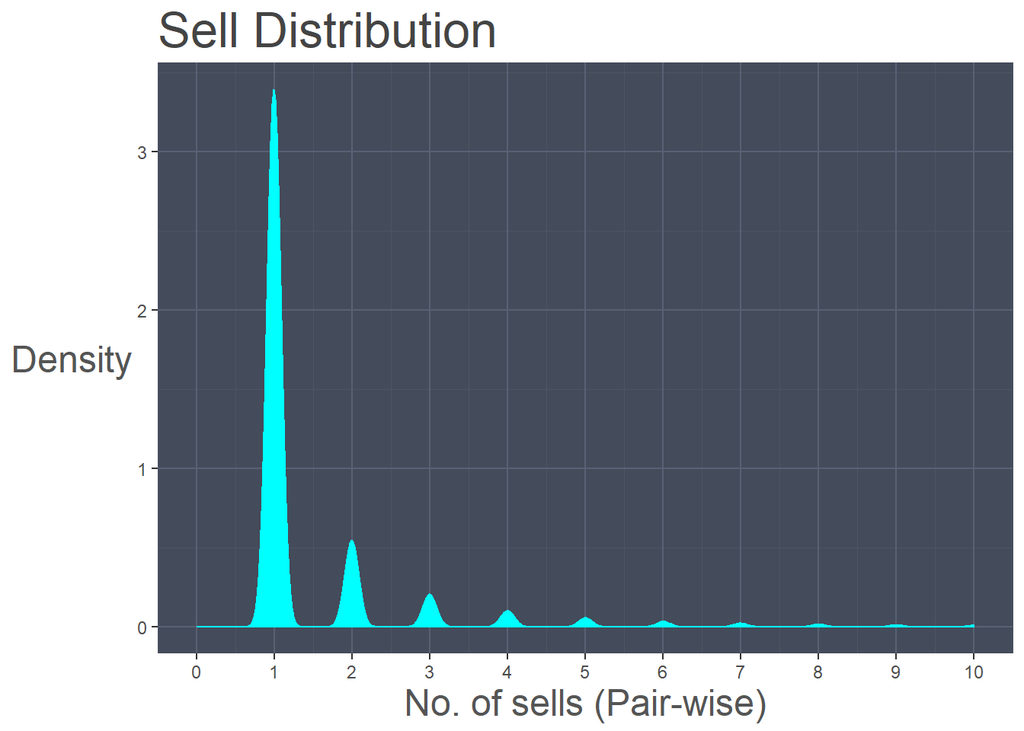

```r
ggplot(data=omisego.pair.users.sells, aes(omisego.pair.users.sells$n)) +
  geom_density(fill='cyan', color='cyan') +
  scale_x_continuous(breaks=seq(0,10,1), limits=c(0,10)) +
  xlab("No. of sells (Pair-wise)") +
  ylab("Density") +
  ggtitle("Sell Distribution") +
  theme(text = element_text(color = "#444444")
        ,panel.background = element_rect(fill = '#444B5A')
        ,panel.grid.minor = element_line(color = '#4d5566')
        ,panel.grid.major = element_line(color = '#586174')
        ,plot.title = element_text(size = 24)
        ,axis.title = element_text(size = 18, color = '#555555')
        ,axis.title.y = element_text(vjust = .5, angle = 0)
        ,axis.title.x = element_text(hjust = .5)
  )
```

###Now that we have seen density distributions for both types of transactions, we’ll individually fit the data in different distribution models

```r
omisego.fit.buy.norm <- fitdist(omisego.pair.users.buys$n, "norm")
omisego.fit.buy.weibull <- fitdist(omisego.pair.users.buys$n, "weibull")
omisego.fit.buy.gamma <- fitdist(omisego.pair.users.buys$n, "gamma")
omisego.fit.buy.lnorm <- fitdist(omisego.pair.users.buys$n, "lnorm")
omisego.fit.buy.exp <- fitdist(omisego.pair.users.buys$n, "exp")
omisego.fit.buy.logis <- fitdist(omisego.pair.users.buys$n, "logis")
```

### Plotting all distributions and check which one satisfies our ‘Buy’ distribution

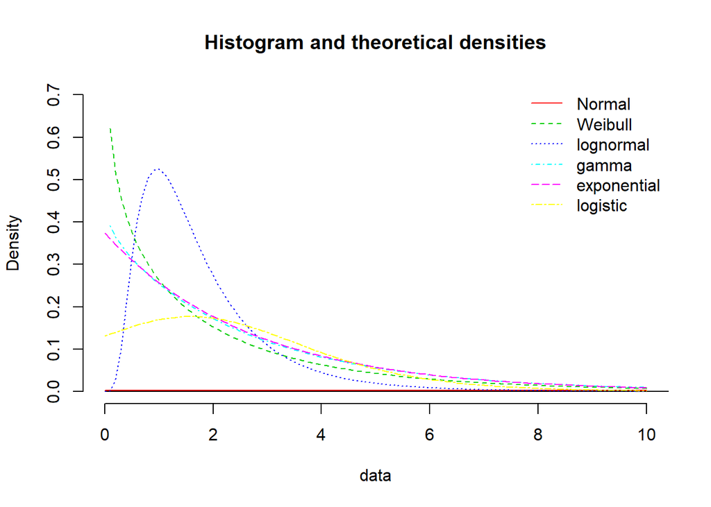

```r
plot.legend <- c("Normal", "Weibull", "lognormal", "gamma", "exponential", "logistic")
denscomp(list(omisego.fit.buy.norm,omisego.fit.buy.weibull , omisego.fit.buy.lnorm, omisego.fit.buy.gamma, omisego.fit.buy.exp,omisego.fit.buy.logis), legendtext = plot.legend, xlim=c(0,10), ylim=c(0,0.7))
```

```r
gofstat(list(omisego.fit.buy.norm,omisego.fit.buy.weibull , omisego.fit.buy.lnorm, omisego.fit.buy.gamma, omisego.fit.buy.exp,omisego.fit.buy.logis),fitnames = c("Normal", "Weibull", "Lognormal", "Gamma", "Exponential", "Logistic"))
```

```
## Goodness-of-fit statistics
##                                    Normal      Weibull    Lognormal
## Kolmogorov-Smirnov statistic 4.952826e-01 4.225091e-01 3.897757e-01
## Cramer-von Mises statistic   3.391556e+04 1.456020e+04 1.181344e+04
## Anderson-Darling statistic            Inf          Inf          Inf
##                                     Gamma  Exponential     Logistic
## Kolmogorov-Smirnov statistic 3.478873e-01 3.581465e-01 3.964921e-01
## Cramer-von Mises statistic   1.545214e+04 1.575061e+04 1.459751e+04
## Anderson-Darling statistic            Inf          Inf          Inf
##
## Goodness-of-fit criteria
##                                 Normal Weibull Lognormal   Gamma
## Akaike's Information Criterion 5339492 1548641   1131323 1661562
## Bayesian Information Criterion 5339514 1548663   1131345 1661584
##                                Exponential Logistic
## Akaike's Information Criterion     1662229  2171728
## Bayesian Information Criterion     1662240  2171750
```

#### From the goodness of fit statistics and the previous graph, it seems lognormal is a better fit than the rest.

#### Estimating parmaters for this distribution

```r
omisego.fit.buy.lnorm
```

```
## Fitting of the distribution ' lnorm ' by maximum likelihood
## Parameters:
##          estimate   Std. Error
## meanlog 0.3736658 0.0009923673
## sdlog   0.6423653 0.0007017020
```

```r
omisego.ests.buys <- bootdist(omisego.fit.buy.lnorm, niter = 100)
summary(omisego.ests.buys)
```

```
## Parametric bootstrap medians and 95% percentile CI
##            Median      2.5%     97.5%
## meanlog 0.3735306 0.3715744 0.3754301
## sdlog   0.6423995 0.6410239 0.6438085
```

#### Now fitting distributions for sell transactions.

```r
omisego.fit.sell.norm <- fitdist(omisego.pair.users.sells$n, "norm")
omisego.fit.sell.weibull <- fitdist(omisego.pair.users.sells$n, "weibull")
omisego.fit.sell.gamma <- fitdist(omisego.pair.users.sells$n, "gamma")
omisego.fit.sell.lnorm <- fitdist(omisego.pair.users.sells$n, "lnorm")
omisego.fit.sell.exp <- fitdist(omisego.pair.users.sells$n, "exp")
omisego.fit.sell.logis <- fitdist(omisego.pair.users.sells$n, "logis")
```

#### Plotting all distributions and check which one satisfies our ‘Sell’ distribution

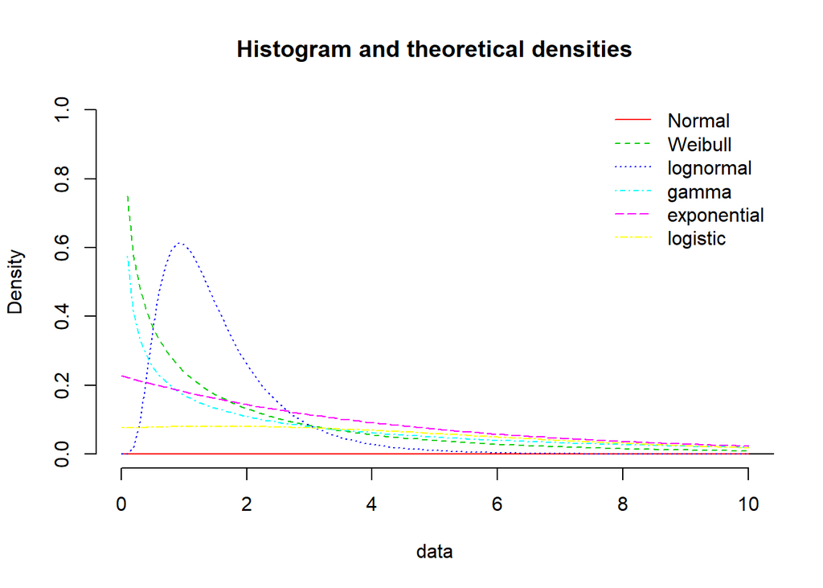

```r
plot.legend <- c("Normal","Weibull", "lognormal", "gamma", "exponential", "logistic")
denscomp(list(omisego.fit.sell.norm, omisego.fit.sell.weibull, omisego.fit.sell.lnorm, omisego.fit.sell.gamma, omisego.fit.sell.exp,omisego.fit.sell.logis), legendtext = plot.legend, xlim=c(0,10), ylim=c(0,1))
```

```r
gofstat(list(omisego.fit.sell.norm, omisego.fit.sell.weibull, omisego.fit.sell.lnorm, omisego.fit.sell.gamma, omisego.fit.sell.exp,omisego.fit.sell.logis),fitnames = c("Normal", "Weibull", "Lognormal", "Gamma", "Exponential", "Logistic"))
```

```
## Goodness-of-fit statistics
##                                    Normal      Weibull    Lognormal
## Kolmogorov-Smirnov statistic 4.969855e-01     0.459155 4.387477e-01
## Cramer-von Mises statistic   2.110318e+04 12148.141554 1.018560e+04
## Anderson-Darling statistic            Inf          Inf          Inf
##                                     Gamma  Exponential     Logistic
## Kolmogorov-Smirnov statistic 4.041902e-01 5.564261e-01 4.578377e-01
## Cramer-von Mises statistic   1.499422e+04 2.505084e+04 1.465832e+04
## Anderson-Darling statistic            Inf          Inf          Inf
##
## Goodness-of-fit criteria
##                                 Normal  Weibull Lognormal   Gamma
## Akaike's Information Criterion 3843712 941355.8  593245.4 1171795
## Bayesian Information Criterion 3843733 941376.7  593266.3 1171816
##                                Exponential Logistic
## Akaike's Information Criterion     1266150  1773038
## Bayesian Information Criterion     1266160  1773059
```

#### From the goodness of fit statistics and the previous graph, it seems lognormal is a better fit than the rest

#### Estimating parmaters for this distribution

```r
omisego.fit.sell.lnorm
```

```
## Fitting of the distribution ' lnorm ' by maximum likelihood
## Parameters:
##          estimate   Std. Error
## meanlog 0.2726650 0.0011642454
## sdlog   0.5884083 0.0008232351
```

```r
omisego.ests.sells <- bootdist(omisego.fit.sell.lnorm, niter = 100)
summary(omisego.ests.sells)
```

```
## Parametric bootstrap medians and 95% percentile CI
##            Median     2.5%    97.5%
## meanlog 0.2728205 0.271124 0.274846
## sdlog   0.5883329 0.586538 0.589843
```

# Question 2

### To get top buyers and sellers in the 3 tokens, we’ll arrange the data in descending order for each of the summarised data

```r
golem.buyers <- pair.users.buys %>% arrange(-n)
golem.sellers <- pair.users.sells %>% arrange(-n)

yocoin.buyers <- yocoin.pair.users.buys %>% arrange(-n)
yocoin.sellers <- yocoin.pair.users.sells %>% arrange(-n)

omisego.buyers <- omisego.pair.users.buys %>% arrange(-n)
omisego.sellers <- omisego.pair.users.sells %>% arrange(-n)
```

## We’ll create a regression model for token ‘Golem’

### Taking K-value as 20 i.e. top 20 buyers, we’ll build a regression model based on number of buys with total tokenAmount as outcome

```r
golem.buyers.20 <- head(golem.buyers,20)
golem.buyers.20
```

| toAddress | n | sumAmount |
| --- | --- | --- |
| 2335455 | 93293 | 2.860954e+26 |
| 4067724 | 7020 | 4.100626e+25 |
| 4092385 | 5452 | 1.327863e+26 |
| 49 | 5192 | 1.618567e+26 |
| 5 | 3709 | 5.148434e+25 |
| 75994 | 3545 | 1.152656e+26 |
| 4067686 | 3447 | 1.018329e+26 |
| 297031 | 3081 | 1.239665e+25 |
| 4067819 | 2963 | 1.086721e+26 |
| 104502 | 2548 | 6.197360e+24 |

[output cut: 10 more lines]

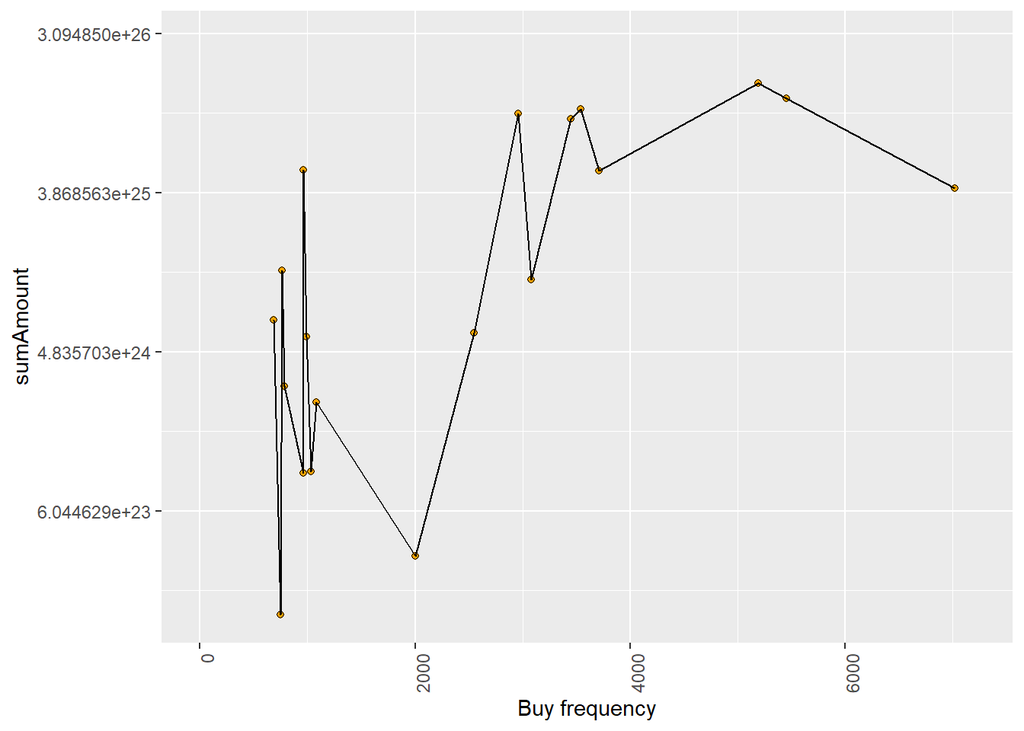

```r
#golem.buyers.20.data <- filteredGolemTX[filteredGolemTX$toAddress %in% golem.buyers.20, ]
#golem.buyers.20.data$toAddress <- as.character(golem.buyers.20.data$toAddress)
ggplot(aes(x=n,y=sumAmount), data = golem.buyers.20) +
  geom_point(fill="orange", color='black', shape=21) +
  scale_y_continuous(trans='log2') +
  xlab("Buy frequency") +
  xlim(0,7200) +
  theme(axis.text.x = element_text(angle = 90, hjust = 1)) +
  geom_line()
```

```r
cor(golem.buyers.20$n, golem.buyers.20$sumAmount)
```

```
## [1] 0.7613258
```

#### We can see that there there some corealtion between the number of buys and total token amount

```r
linearMod <- lm(sumAmount ~ n, data=golem.buyers.20)  # build linear regression model on full data
print(linearMod)
```

```
##
## Call:
## lm(formula = sumAmount ~ n, data = golem.buyers.20)
##
## Coefficients:
## (Intercept)            n
##   3.553e+25    2.810e+21
```

```r
summary(linearMod)
```

```
##
## Call:
## lm(formula = sumAmount ~ n, data = golem.buyers.20)
##
## Residuals:
##        Min         1Q     Median         3Q        Max
## -4.083e+25 -3.618e+25 -2.692e+25  2.438e+25  1.117e+26
##
## Coefficients:
##              Estimate Std. Error t value Pr(>|t|)
## (Intercept) 3.553e+25  1.189e+25   2.988  0.00788 **
## n           2.810e+21  5.641e+20   4.982 9.66e-05 ***
## ---
## Signif. codes:  0 '***' 0.001 '**' 0.01 '*' 0.05 '.' 0.1 ' ' 1
##
## Residual standard error: 5.014e+25 on 18 degrees of freedom
## Multiple R-squared:  0.5796, Adjusted R-squared:  0.5563
## F-statistic: 24.82 on 1 and 18 DF,  p-value: 9.658e-05
```

```r
modelSummary <- summary(linearMod)  # capture model summary as an object
modelCoeffs <- modelSummary$coefficients  # model coefficients
beta.estimate <- modelCoeffs["n", "Estimate"]  # get beta estimate for frequency of buys
std.error <- modelCoeffs["n", "Std. Error"]  # get std.error for frequency of buys
t_value <- beta.estimate/std.error  # calc t statistic
p_value <- 2*pt(-abs(t_value), df=nrow(golem.buyers.20)-ncol(golem.buyers.20))  # calc p Value
f_statistic <- linearMod$fstatistic[1]  # fstatistic
f <- summary(linearMod)$fstatistic  # parameters for model p-value calc
model_p <- pf(f[1], f[2], f[3], lower=FALSE)
```

```r
p_value
```

```
## [1] 0.0001138393
```

#### Akaike’s information criterion - AIC (Akaike, 1974); We’ll use this criteria to determine the best linear model. Lower score is preferred.

```r
AIC(linearMod)
```

```
## [1] 2427.724
```

### Taking K-value as 100 i.e. top 100 buyers, we’ll build a regression model based on number of buys with total tokenAmount as outcome

```r
golem.buyers.100 <- head(golem.buyers,100)
golem.buyers.100
```

| toAddress | n | sumAmount |
| --- | --- | --- |
| 2335455 | 93293 | 2.860954e+26 |
| 4067724 | 7020 | 4.100626e+25 |
| 4092385 | 5452 | 1.327863e+26 |
| 49 | 5192 | 1.618567e+26 |
| 5 | 3709 | 5.148434e+25 |
| 75994 | 3545 | 1.152656e+26 |
| 4067686 | 3447 | 1.018329e+26 |
| 297031 | 3081 | 1.239665e+25 |
| 4067819 | 2963 | 1.086721e+26 |
| 104502 | 2548 | 6.197360e+24 |

[output cut: 90 more lines]

```r
cor(golem.buyers.100$n, golem.buyers.100$sumAmount)
```

```
## [1] 0.7634644
```

```r
linearMod2 <- lm(sumAmount ~ n, data=golem.buyers.100)  # build linear regression model on full data
print(linearMod)
```

```
##
## Call:
## lm(formula = sumAmount ~ n, data = golem.buyers.20)
##
## Coefficients:
## (Intercept)            n
##   3.553e+25    2.810e+21
```

```r
modelSummary2 <- summary(linearMod2)  # capture model summary as an object
modelCoeffs2 <- modelSummary2$coefficients  # model coefficients
beta.estimate2 <- modelCoeffs2["n", "Estimate"]  # get beta estimate for frequency of buys
std.error2 <- modelCoeffs2["n", "Std. Error"]  # get std.error for frequency of buys
t_value2 <- beta.estimate2/std.error2  # calc t statistic
p_value2 <- 2*pt(-abs(t_value2), df=nrow(golem.buyers.100)-ncol(golem.buyers.100))  # calc p Value
f_statistic2 <- linearMod$fstatistic[1]  # fstatistic
f2 <- summary(linearMod)$fstatistic  # parameters for model p-value calc
model_p2 <- pf(f2[1], f2[2], f2[3], lower=FALSE)
```

```r
p_value
```

```
## [1] 0.0001138393
```

```r
AIC(linearMod2)
```

```
## [1] 11988.78
```

#### For Golem token, the number of buys with K value 20 fares better than K value of 100; therefore, K-value of 20 is preferred for number of buys vs totalTokenAmount linear regression model

## Regression model for token ‘Yocoin’

#### Taking K-value as 50 i.e. top 50 buyers, we’ll build a regression model based on number of buys with total tokenAmount as outcome

```r
yocoin.buyers.50 <- head(yocoin.buyers,50)
yocoin.buyers.50
```

| toAddress | n | sumAmount |
| --- | --- | --- |
| 9911653 | 14758 | 2.703289e+25 |
| 309659 | 7000 | 2.217672e+24 |
| 9912976 | 6219 | 2.283762e+22 |
| 9916042 | 6110 | 4.366891e+21 |
| 9915788 | 5622 | 4.712654e+21 |
| 9913800 | 4518 | 9.086639e+21 |
| 9916338 | 4286 | 9.890930e+20 |
| 9911955 | 3028 | 5.166225e+21 |
| 9912979 | 3012 | 1.097888e+22 |
| 9913169 | 2879 | 4.245897e+21 |

[output cut: 40 more lines]

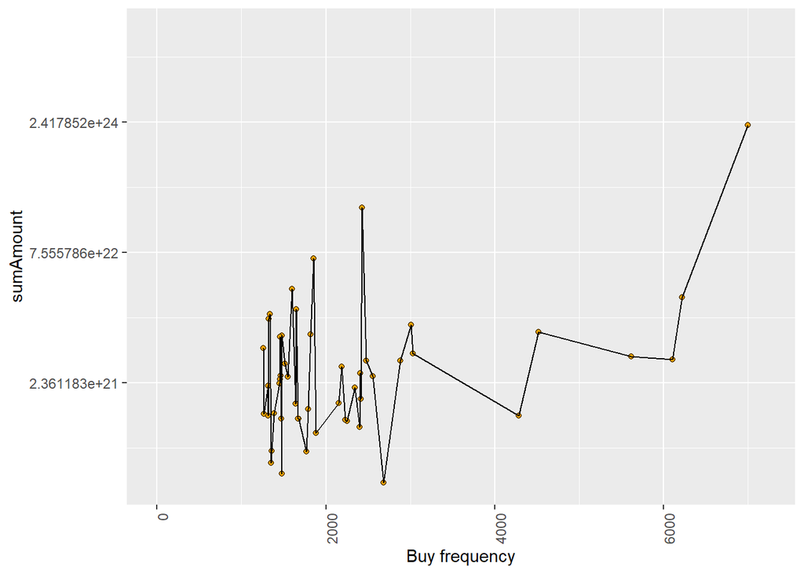

```r
ggplot(aes(x=n,y=sumAmount), data = yocoin.buyers.50) +
  geom_point(fill="orange", color='black', shape=21) +
  scale_y_continuous(trans='log2') +
  xlab("Buy frequency") +
  xlim(0,7200) +
  theme(axis.text.x = element_text(angle = 90, hjust = 1)) +
  geom_line()
```

```r
cor(yocoin.buyers.50$n, yocoin.buyers.50$sumAmount)
```

```
## [1] 0.811942
```

```r
linearMod3 <- lm(sumAmount ~ n, data=yocoin.buyers.50)  # build linear regression model on full data
summary(linearMod3)
```

```
##
## Call:
## lm(formula = sumAmount ~ n, data = yocoin.buyers.50)
##
## Residuals:
##        Min         1Q     Median         3Q        Max
## -5.663e+24 -3.770e+23  5.102e+23  9.562e+23  9.430e+24
##
## Coefficients:
##               Estimate Std. Error t value Pr(>|t|)
## (Intercept) -2.993e+24  4.905e+23  -6.101 1.75e-07 ***
## n            1.396e+21  1.448e+20   9.637 8.39e-13 ***
## ---
## Signif. codes:  0 '***' 0.001 '**' 0.01 '*' 0.05 '.' 0.1 ' ' 1
##
## Residual standard error: 2.258e+24 on 48 degrees of freedom
## Multiple R-squared:  0.6592, Adjusted R-squared:  0.6522
## F-statistic: 92.87 on 1 and 48 DF,  p-value: 8.387e-13
```

```r
modelSummary3 <- summary(linearMod3)  # capture model summary as an object
modelCoeffs3 <- modelSummary3$coefficients  # model coefficients
beta.estimate3 <- modelCoeffs3["n", "Estimate"]  # get beta estimate for frequency of buys
std.error3 <- modelCoeffs3["n", "Std. Error"]  # get std.error for frequency of buys
t_value3 <- beta.estimate3/std.error3  # calc t statistic
p_value3 <- 2*pt(-abs(t_value3), df=nrow(yocoin.buyers.50)-ncol(yocoin.buyers.50))  # calc p Value
f_statistic3 <- linearMod3$fstatistic[1]  # fstatistic
f3 <- summary(linearMod3)$fstatistic  # parameters for model p-value calc
model_p3 <- pf(f3[1], f3[2], f3[3], lower=FALSE)
```

```r
model_p3
```

```
##        value
## 8.387138e-13
```

```r
AIC(linearMod3)
```

```
## [1] 5753.492
```

### Taking K-value as 200 i.e. top 200 buyers, we’ll build a regression model based on number of buys with total tokenAmount as outcome

```r
yocoin.buyers.200 <- head(yocoin.buyers,200)
yocoin.buyers.200
```

| toAddress | n | sumAmount |
| --- | --- | --- |
| 9911653 | 14758 | 2.703289e+25 |
| 309659 | 7000 | 2.217672e+24 |
| 9912976 | 6219 | 2.283762e+22 |
| 9916042 | 6110 | 4.366891e+21 |
| 9915788 | 5622 | 4.712654e+21 |
| 9913800 | 4518 | 9.086639e+21 |
| 9916338 | 4286 | 9.890930e+20 |
| 9911955 | 3028 | 5.166225e+21 |
| 9912979 | 3012 | 1.097888e+22 |
| 9913169 | 2879 | 4.245897e+21 |

[output cut: 190 more lines]

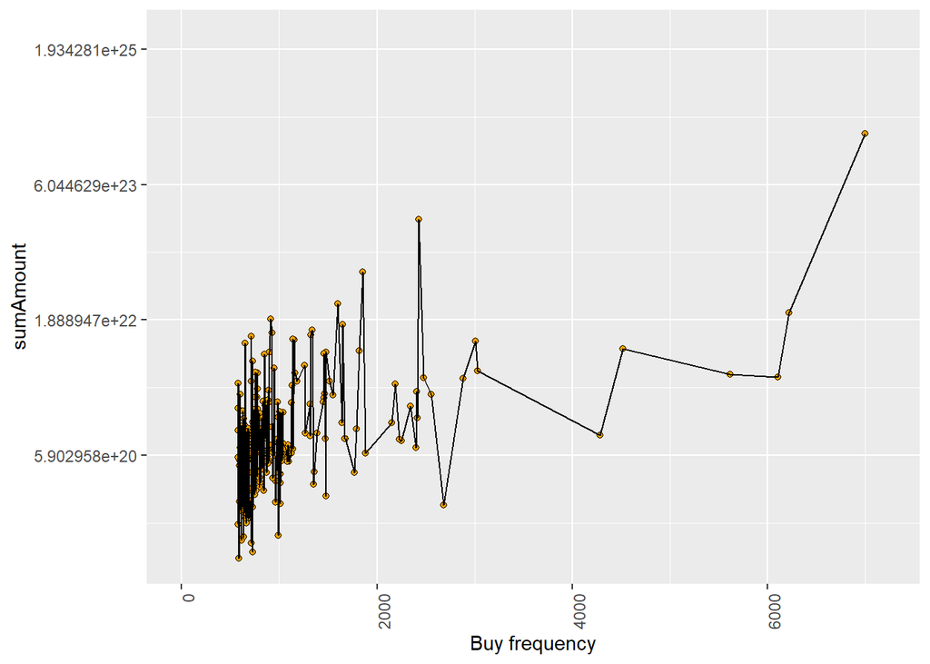

```r
ggplot(aes(x=n,y=sumAmount), data = yocoin.buyers.200) +
  geom_point(fill="orange", color='black', shape=21) +
  scale_y_continuous(trans='log2') +
  xlab("Buy frequency") +
  xlim(0,7200) +
  theme(axis.text.x = element_text(angle = 90, hjust = 1)) +
  geom_line()
```

```r
cor(yocoin.buyers.200$n, yocoin.buyers.200$sumAmount)
```

```
## [1] 0.7337611
```

#### Corelation decrease when we take K-value as 200; taking k-value as 30, i.e. top 30 buyers

```r
yocoin.buyers.30 <- head(yocoin.buyers,30)
yocoin.buyers.30
```

| toAddress | n | sumAmount |
| --- | --- | --- |
| 9911653 | 14758 | 2.703289e+25 |
| 309659 | 7000 | 2.217672e+24 |
| 9912976 | 6219 | 2.283762e+22 |
| 9916042 | 6110 | 4.366891e+21 |
| 9915788 | 5622 | 4.712654e+21 |
| 9913800 | 4518 | 9.086639e+21 |
| 9916338 | 4286 | 9.890930e+20 |
| 9911955 | 3028 | 5.166225e+21 |
| 9912979 | 3012 | 1.097888e+22 |
| 9913169 | 2879 | 4.245897e+21 |

[output cut: 20 more lines]

```r
cor(yocoin.buyers.30$n, yocoin.buyers.30$sumAmount)
```

```
## [1] 0.844551
```

#### We observe that corelation increases when we take a lesser k-value. We’ll proceed with this value and create the regression model

```r
linearMod4 <- lm(sumAmount ~ n, data=yocoin.buyers.30)  # build linear regression model on full data
summary(linearMod4)
```

```
##
## Call:
## lm(formula = sumAmount ~ n, data = yocoin.buyers.30)
##
## Residuals:
##        Min         1Q     Median         3Q        Max
## -5.554e+24 -4.110e+23  5.459e+23  1.404e+24  7.866e+24
##
## Coefficients:
##               Estimate Std. Error t value Pr(>|t|)
## (Intercept) -4.320e+24  8.037e+23  -5.376 9.94e-06 ***
## n            1.591e+21  1.907e+20   8.346 4.44e-09 ***
## ---
## Signif. codes:  0 '***' 0.001 '**' 0.01 '*' 0.05 '.' 0.1 ' ' 1
##
## Residual standard error: 2.69e+24 on 28 degrees of freedom
## Multiple R-squared:  0.7133, Adjusted R-squared:  0.703
## F-statistic: 69.65 on 1 and 28 DF,  p-value: 4.435e-09
```

```r
modelSummary4 <- summary(linearMod4)  # capture model summary as an object
modelCoeffs4 <- modelSummary4$coefficients  # model coefficients
beta.estimate4 <- modelCoeffs4["n", "Estimate"]  # get beta estimate for frequency of buys
std.error4 <- modelCoeffs4["n", "Std. Error"]  # get std.error for frequency of buys
t_value4 <- beta.estimate4/std.error4  # calc t statistic
p_value4 <- 2*pt(-abs(t_value4), df=nrow(yocoin.buyers.30)-ncol(yocoin.buyers.30))  # calc p Value
f_statistic4 <- linearMod4$fstatistic[1]  # fstatistic
f4 <- summary(linearMod3)$fstatistic  # parameters for model p-value calc
model_p3 <- pf(f4[1], f4[2], f4[3], lower=FALSE)
```

```r
model_p3
```

```
##        value
## 8.387138e-13
```

```r
AIC(linearMod4)
```

```
## [1] 3464.153
```

#### AIC value for k=30 is lower than than when k=50; We’ll conclude that k=30 is a better model for token ‘Yocoin’